# Pipeline: miRNA

María Araceli Hernández Betancor

24 de junio, 2020

# DATASET: GSE54578

Una vez instalados los paquetes de Bioconductor necesarios para el análisis de datos de *microarray* de miRNA, se desacarga el *dataset* GSE54578 de la página web Pubmed (https://www.ncbi.nlm.nih.gov/geo/query/acc.cgi?acc=GSE54578). El estudio analiza la expresión de miRNA de todo el genoma en sangre de 15 casos de esquizofrenia (SZ) de inicio temprano (EOS) y 15 controles sanos. Los microarrays de muestras detectaron un total de 1070 miRNAs. Se analiza la expresión de miRNA en 15 muestras de pacientes con esquizofrenia y 15 controles sanos para explorar la alteración de los miRNA en la esquizofrenia, siguiendo el flujo de trabajo propuesto por *Emilio Mastriani et al.* Se utiliza la plataforma GPL16016 (Exiqon miRCURY LNA microRNA array). Se puede realizar la descarga directamente mediante el enlace, o a través del paquete *“GEOquery”* y la función *“getGEO”*. Finalmente se guarda el conjunto de datos en *gset*, para su posterior procesamiento y análisis.

```r
library("GEOquery")
gset<-getGEO("GSE54578", GSEMatrix=TRUE, AnnotGPL=FALSE)
if(length(gset)>1) idx <-grep("GPL1606", attr(gset,"-names")) else idx<-1
gset<-gset[[idx]]
```

# PREPROCESAMIENTO

Los datos de expresión miRNA pueden tener valores perdidos “NA” y las columnas son nominadas como “GSM”. Se puede mostrar la estructura de los datos, y extraer inicialmente los regitros con valores perdidos y renombrar las columnas para facilitar su lectura (SCHIZ, CTRL).

```r
head(exprs(gset)) ## Se visualiza la presencia de valores perdidos
```

```
      GSM1319258  GSM1319259 GSM1319260 GSM1319261 GSM1319262 GSM1319263 GSM1319264
4610   0.4464805  0.59599354  1.3857880 -0.1584685 -3.5064605  0.2568499  0.6547877
4700   0.1128415 -0.08805618  1.0623719  0.6509808 -4.1818383  0.8375980  0.2771786
5730  -5.1601770 -4.24792751 -4.2286244 -4.0231896 -3.1186445 -3.9096360 -3.1292830
6880  -8.2045709 -7.66296487 -8.5360526 -8.3630395 -5.9259995 -7.7169908 -6.9872641
9938   0.2132814  0.48169323  1.1406094 -0.0927443 -0.9373147  0.2006795  0.4189410
10138 -1.6499823  0.35940280  0.5524704 -0.8592139 -3.4535116 -1.2155517 -0.6766512
      GSM1319265 GSM1319266 GSM1319267 GSM1319268 GSM1319269 GSM1319270 GSM1319271
4610  -1.2473593 -0.7183438 -0.4821903  -1.260937  -1.172444  -2.015682 -0.3828823
4700  -2.7915300 -2.6722474 -2.0842263  -3.190398  -2.815288  -3.443919 -2.3795388
5730  -4.2801079 -4.3127050 -5.2438829  -4.503375  -4.242185  -5.803461 -5.7193888
6880  -6.9879272 -7.5256988 -7.3390403  -8.295933  -7.970106  -7.724026 -8.7193890
9938  -0.9984854 -0.6609498 -0.9021394  -1.425568  -1.407863  -1.565597 -1.1213363
10138 -2.6047989 -2.1777755 -1.9127754  -1.971431  -2.182203  -4.381634 -1.4156081
      GSM1319272 GSM1319273 GSM1319274  GSM1319275 GSM1319276 GSM1319277 GSM1319278
```

[output cut: 20 more lines]

```r
rmv<-which(apply(exprs(gset),1,function(x) any (is.na(x))))
```

```r
gset<-gset[-rmv,]
sampleNames(gset)<-c("CTRL1","CTRL2","CTRL3","CTRL4","CTRL5","CTRL6","CTRL7","CTRL8","CTRL9","CTRL10","CTRL11","CTRL12","CTRL13","CTRL14","CTRL15","SCHIZO1","SCHIZO2","SCHIZO3","SCHIZO4","SCHIZO5","SCHIZO6","SCHIZO7","SCHIZO8","SCHIZO9","SCHIZO10","SCHIZO11","SCHIZO12","SCHIZO13","SCHIZO14","SCHIZO15")
gsms<-"000000000000000111111111111111"
sml<-c()
for(i in 1:nchar(gsms)) {sml[i]<-substr(gsms,i,i)}
head(exprs(gset))
```

```
           CTRL1       CTRL2     CTRL3      CTRL4      CTRL5      CTRL6      CTRL7
4610   0.4464805  0.59599354  1.385788 -0.1584685 -3.5064605  0.2568499  0.6547877
4700   0.1128415 -0.08805618  1.062372  0.6509808 -4.1818383  0.8375980  0.2771786
9938   0.2132814  0.48169323  1.140609 -0.0927443 -0.9373147  0.2006795  0.4189410
10306 -1.2102177 -2.81329928 -1.749457 -2.3518124 -3.5474878 -1.8101003 -1.9265681
10919 -0.0159823  0.72576985  1.249236  0.3234609 -0.9625253  0.3053769  0.4071987
10923  0.8370880  1.44512378  2.581850  1.7047308 -0.4166203  1.9412206  1.4793223
           CTRL8      CTRL9     CTRL10    CTRL11    CTRL12    CTRL13     CTRL14    CTRL15
4610  -1.2473593 -0.7183438 -0.4821903 -1.260937 -1.172444 -2.015682 -0.3828823 -1.157132
4700  -2.7915300 -2.6722474 -2.0842263 -3.190398 -2.815288 -3.443919 -2.3795388 -2.425711
9938  -0.9984854 -0.6609498 -0.9021394 -1.425568 -1.407863 -1.565597 -1.1213363 -1.270141
10306 -4.9175379 -4.4615684 -4.3722070 -5.643856 -5.415517 -6.007819 -3.9512045 -4.968445
10919 -1.6878034 -1.0812485 -0.9467228 -1.206955 -1.533394 -2.597691 -0.8291245 -1.043176
10923 -1.6540264 -1.1506593 -1.1856033 -1.562191 -1.820359 -2.763197 -1.5394797 -1.616317
         SCHIZO1    SCHIZO2    SCHIZO3   SCHIZO4   SCHIZO5    SCHIZO6    SCHIZO7
4610   0.7779281  0.5872010  0.9637209 -3.012142 -1.805000 -0.9869923  1.0405705
4700   0.2163341 -1.1337002  0.6316126 -3.824641 -2.374745 -2.6215475 -0.2676708
9938   0.3041216  0.4479816  0.6917758 -2.699485 -1.235020 -1.1327459  0.7959210
10306 -2.0271848 -3.3422322 -2.2378033 -5.937115 -6.420887 -4.9915699 -2.7481527
10919  0.8790086  0.7605185  1.2124274 -2.711940 -1.191299 -1.1720403  1.0567319
10923  1.4981941  0.7492344  2.2620983 -2.833686 -1.081749 -1.1548241  1.6359137
        SCHIZO8   SCHIZO9  SCHIZO10  SCHIZO11  SCHIZO12   SCHIZO13  SCHIZO14  SCHIZO15
4610  -5.457443 -1.204358 -1.698946 -3.264817 -4.565913 -1.8447689 -2.439081 2.1339084
4700  -3.631472 -3.512192 -3.073581 -4.194114 -4.797239 -3.9301604 -2.738306 4.4644310
9938  -4.857981 -1.927229 -1.632567 -2.481184 -3.366604 -0.7254700 -1.670217 1.6198764
10306 -6.414374 -6.360189 -5.799406 -7.039605 -8.320801 -5.6438562 -5.350336 1.7642502
10919 -4.479469 -1.602632 -1.885136 -2.722192 -3.606555 -0.9930916 -2.255179 3.2705074
10923 -4.273018 -1.659749 -2.261441 -3.079603 -3.579334 -1.5129253 -2.585766 0.3956792
```

Se comprueba gráficamente la intensidades de sonda para buscar posibles *outliers*, que podrían ser excluidos de un análisis posterior. Se observa la uniformidad de la intensidad de la señal a través de la función *“boxplot()”*, con escasa variabilidad entre los arrays.

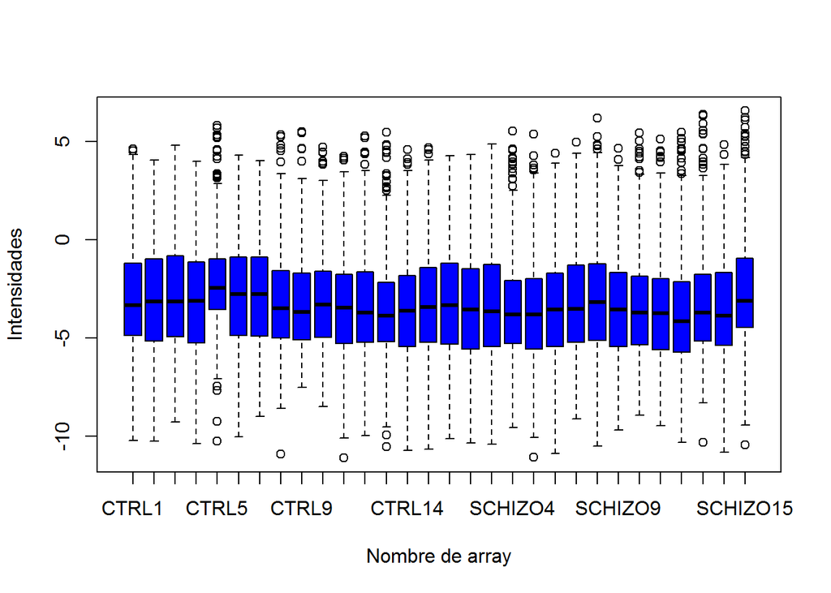

```r
ex<-exprs(gset)
boxplot(ex, which="pm", ylab="Intensidades", xlab="Nombre de array", col="blue")
```